# World Population Exploratory Data Analysis (1970–2022)

## Recent Population Growth (2020–2022)

We compute the growth ratio between 2022 and 2020 and show the top 5 countries with the highest growth.

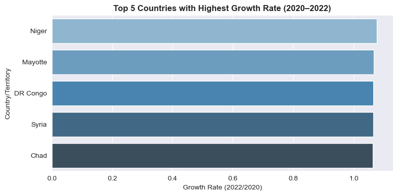

```python
df['Growth_Rate_2020_to_2022'] = (df['2022 Population'] / df['2020 Population']).round(4)
top_growth_recent = (df[['Country/Territory','Growth_Rate_2020_to_2022']]
                      .sort_values(by='Growth_Rate_2020_to_2022', ascending=False)
                      .head())

plt.figure(figsize=(8,4))
sns.barplot(data=top_growth_recent, x='Growth_Rate_2020_to_2022', y='Country/Territory', palette='Blues_d')
plt.title("Top 5 Countries with Highest Growth Rate (2020–2022)", fontweight='bold')
plt.xlabel("Growth Rate (2022/2020)")
plt.tight_layout()
plt.show()
```

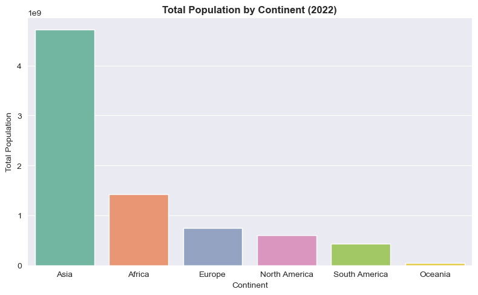

```python
continent_pop = (df.groupby('Continent')['2022 Population']
                   .sum()
                   .sort_values(ascending=False)
                   .reset_index())

plt.figure(figsize=(8,5))
sns.barplot(data=continent_pop, x='Continent', y='2022 Population', palette='Set2')
plt.title("Total Population by Continent (2022)", fontweight='bold')
plt.ylabel("Total Population")
plt.tight_layout()
plt.show()
```

## Country Area vs. Population (2022)

A scatter plot to see if larger area implies larger population (spoiler: not really).

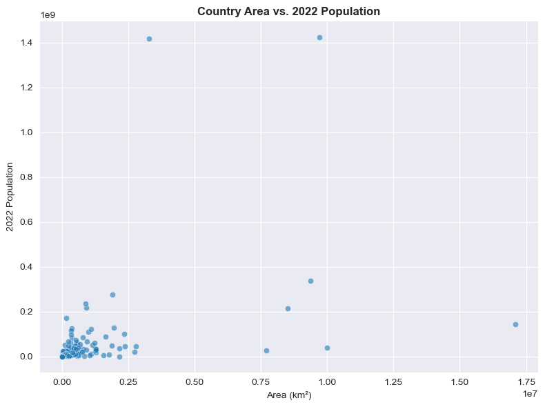

```python
plt.figure(figsize=(8,6))
sns.scatterplot(data=df, x='Area (km²)', y='2022 Population', alpha=0.6)
plt.title("Country Area vs. 2022 Population", fontweight='bold')
plt.tight_layout()
plt.show()
```

## Countries with Highest Overall Growth Rate

The dataset provides a `Growth Rate` column (presumably average annual growth?). We'll plot the top 10.

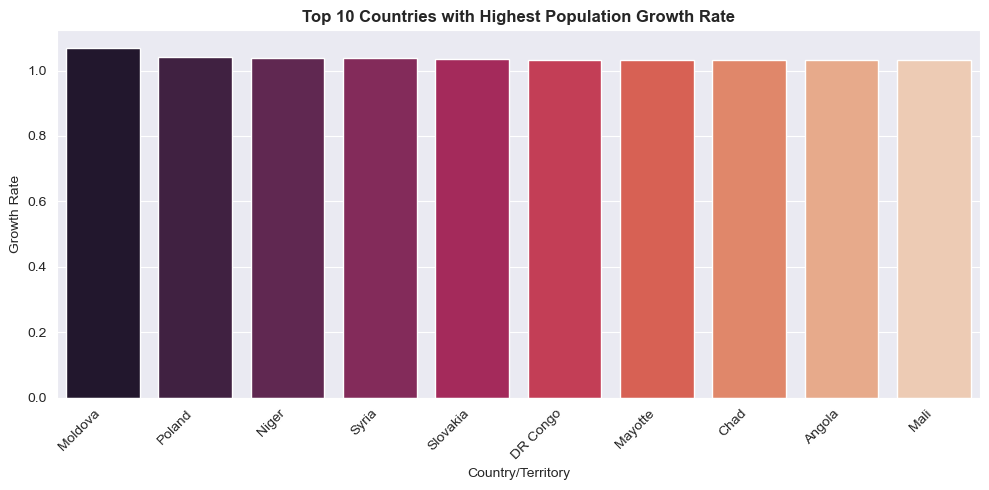

```python
top_growth = (df[['Country/Territory','Growth Rate']]
              .sort_values(by='Growth Rate', ascending=False)
              .head(10))

plt.figure(figsize=(10,5))
sns.barplot(data=top_growth, x='Country/Territory', y='Growth Rate', palette='rocket')
plt.title("Top 10 Countries with Highest Population Growth Rate", fontweight='bold')
plt.xticks(rotation=45, ha='right')
plt.tight_layout()
plt.show()
```

## Share of World Population – Top 5 Countries

Pie chart showing the percentage of world population for the five most populous countries.

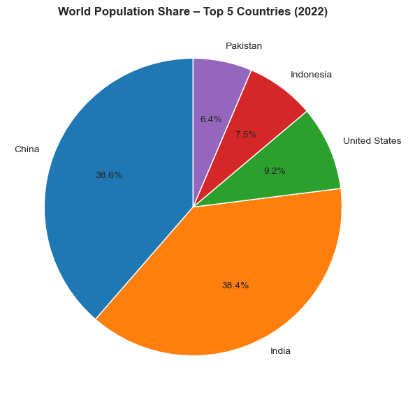

```python
top5_pct = (df[['Country/Territory','World Population Percentage']]
            .sort_values(by='World Population Percentage', ascending=False)
            .head())

plt.figure(figsize=(6,6))
plt.pie(top5_pct['World Population Percentage'], labels=top5_pct['Country/Territory'], autopct='%1.1f%%', startangle=90)
plt.title("World Population Share – Top 5 Countries (2022)", fontweight='bold')
plt.tight_layout()
plt.show()
```

## Continent‑Wise Population Growth Over Time (1970–2022)

We reshape the data to long format and plot the total population per continent for each year.

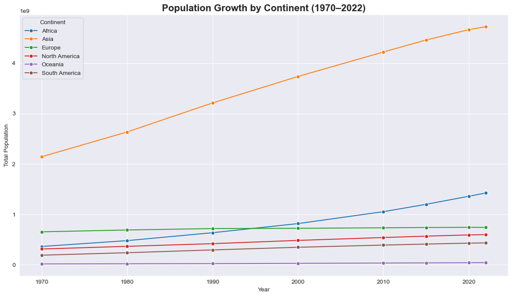

```python
years = [
    '1970 Population',
    '1980 Population',
    '1990 Population',
    '2000 Population',
    '2010 Population',
    '2015 Population',
    '2020 Population',
    '2022 Population'
]

# Melt to long format
pop_long = df.melt(id_vars='Continent', value_vars=years,
                   var_name='Year', value_name='Population')
pop_long['Year'] = pop_long['Year'].str.extract('(\d+)').astype(int)

# Sum by continent and year
continent_trend = pop_long.groupby(['Continent','Year'])['Population'].sum().reset_index()

plt.figure(figsize=(12,7))
sns.lineplot(data=continent_trend, x='Year', y='Population', hue='Continent', marker='o')
plt.title("Population Growth by Continent (1970–2022)", fontsize=16, fontweight='bold')
plt.ylabel("Total Population")
plt.tight_layout()
plt.show()
```

## Largest Absolute Population Increase by Decade

For each decade (1970–1980, 1980–1990, … , 2010–2020) we find the country with the largest absolute population increase and display a bar chart.

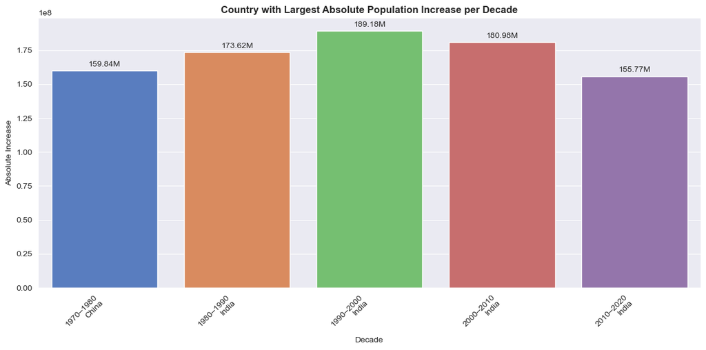

```python
decade_pairs = [
    ('1970 Population', '1980 Population'),
    ('1980 Population', '1990 Population'),
    ('1990 Population', '2000 Population'),
    ('2000 Population', '2010 Population'),
    ('2010 Population', '2020 Population'),
]

records = []
for start, end in decade_pairs:
    increase = df[end] - df[start]
    idx = increase.idxmax()
    records.append({
        'Decade': f"{start[:4]}–{end[:4]}",
        'Country': df.loc[idx, 'Country/Territory'],
        'Increase': increase[idx],
        'Pct': (increase[idx] / df.loc[idx, start] * 100)
    })

decade_df = pd.DataFrame(records)

plt.figure(figsize=(12,6))
ax = sns.barplot(data=decade_df, x='Decade', y='Increase', palette='muted')

# Label bars with country names and formatted increase
xticklabels = [f"{d}\n{c}" for d, c in zip(decade_df['Decade'], decade_df['Country'])]
ax.set_xticklabels(xticklabels, rotation=45, ha='right')

for container in ax.containers:
    labels = [human_format(v) for v in container.datavalues]
    ax.bar_label(container, labels=labels,
     padding=3)

plt.title("Country with Largest Absolute Population Increase per Decade", fontweight='bold')
plt.ylabel("Absolute Increase")
plt.tight_layout()
plt.show()
```

## Correlation Between Growth Rate and Population Density

A scatter plot with a regression line to see if higher density relates to growth rate.

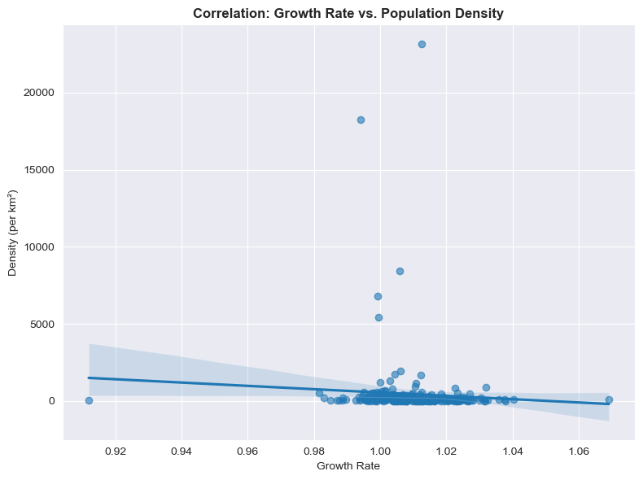

```python
plt.figure(figsize=(8,6))
sns.regplot(data=df, x='Growth Rate', y='Density (per km²)', scatter_kws={'alpha':0.6})
plt.title("Correlation: Growth Rate vs. Population Density", fontweight='bold')
plt.tight_layout()
plt.show()
```